# Homework 02

## Question 1: Training and test error under a fixed design

Consider a linear regression problem with $n=100$ observations and $p=20$ available covariates. Generate one matrix $\mathbf X_{\mathrm{all}}\in\mathbb R^{n\times p}$ whose entries are independent $\mathcal N(0,1)$ random variables, and then keep this realized matrix fixed. Let

$$\beta_j=0.4^{\sqrt{j}},
\qquad j=1,\ldots,p,$$

and define

$$\boldsymbol\mu=\mathbf X_{\mathrm{all}}\boldsymbol\beta.$$

Generate one training response and one independent test response from

$$\begin{aligned}
\mathbf y
&=\boldsymbol\mu+\boldsymbol\epsilon,\\
\mathbf y^*
&=\boldsymbol\mu+\boldsymbol\epsilon^*,
\end{aligned}$$

where

$$\boldsymbol\epsilon,\boldsymbol\epsilon^*
\overset{\mathrm{ind}}{\sim}
\mathcal N_n(\mathbf 0,\mathbf I_n).$$

Here $\mathbf I_n$ is the $n\times n$ identity matrix.

For $m=0,1,\ldots,p$, fit a linear model with an intercept and the first $m$ columns of $\mathbf X_{\mathrm{all}}$ using $\mathbf y$. If $\widehat{\mathbf y}_m$ is its fitted mean vector, define

$$\begin{aligned}
\operatorname{MSE}_{\mathrm{train},m}
&=\frac{1}{n}\left\lVert\mathbf y-\widehat{\mathbf y}_m\right\rVert_2^2,
&\qquad
\operatorname{MSE}_{\mathrm{test},m}
&=\frac{1}{n}\left\lVert\mathbf y^*-\widehat{\mathbf y}_m\right\rVert_2^2.
\end{aligned}$$

Repeat this process independently 200 times, keeping $\mathbf X_{\mathrm{all}}$ fixed.

Use seed `43202` before generating $\mathbf X_{\mathrm{all}}$ and the response errors. R and Python use different random-number generators, so their exact numerical values need not agree.

1. For each $m$, calculate the average training and test MSE over the 200 simulation runs. Plot both curves against $m$. Verify numerically that training MSE does not increase as predictors are added in each simulation run.

$$\mathbf X_m
=
[\mathbf 1,\mathbf x_1,\ldots,\mathbf x_m],
\qquad
\mathbf H_m
=
\mathbf X_m
(\mathbf X_m^{\mathsf T}\mathbf X_m)^{-1}
\mathbf X_m^{\mathsf T}.$$

Here $\mathbf X_m\in\mathbb R^{n\times(m+1)}$ and $\mathbf H_m\in\mathbb R^{n\times n}$. The model has $m+1$ fitted coefficients, including the intercept. Define its **total squared approximation bias** as

$$B_m^2
=\left\lVert
(\mathbf I_n-\mathbf H_m)\boldsymbol\mu
\right\rVert_2^2.$$

Thus, $B_m^2/n$ is the mean squared approximation bias.

Calculate the two theoretical expectations

$$\begin{aligned}
E\!\left(\operatorname{MSE}_{\mathrm{train},m}\mid\mathbf X_{\mathrm{all}}\right)
&=\frac{B_m^2}{n}+1-\frac{m+1}{n},
&\qquad
E\!\left(\operatorname{MSE}_{\mathrm{test},m}\mid\mathbf X_{\mathrm{all}}\right)
&=\frac{B_m^2}{n}+1+\frac{m+1}{n}.
\end{aligned}$$

Add these expectations to your plot and compare them with the simulation averages.

3. Add the test MSE curve from one simulation run to the plot. Explain why this single curve is less smooth than the average test MSE. Use the approximation-bias and estimation-variance terms in the expected test MSE to explain why training MSE cannot be used by itself to select the predictor count.

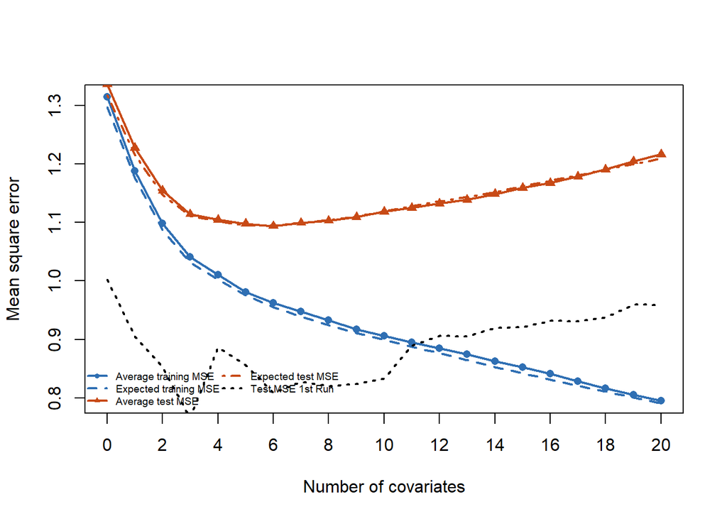

This single curve is less smooth than the average test MSE because the single curve is only based on one training and testing response pair. The randomness, or error, in the response pairs makes the single curve jump. The approximation-bias, $B_m^2/n$, is the error from using too few predictors, and the estimation-variance, $\frac{m + 1}{n}$, is the error from using too many predictors. Training MSE cannot be used by itself to select the predictor count because the training MSE always decreases or stays the same when adding more predictors. Simply adding new predictors does not mean the model can predict new responses well.

## Question 2: Prediction error at one target point

Let $n=100$, $p=6$, and $\sigma^2=1$. Construct the fixed covariate matrix $\mathbf X_{\mathrm{all}}\in\mathbb R^{n\times p}$ with entries

$$(\mathbf X_{\mathrm{all}})_{ij}
=\sqrt{2}\cos\left\{
\frac{\pi j(i-\tfrac12)}{n}
\right\},
\qquad
i=1,\ldots,n,
\quad
j=1,\ldots,p.$$

Its columns satisfy

$$\mathbf 1^{\mathsf T}\mathbf X_{\mathrm{all}}=\mathbf 0^{\mathsf T},
\qquad
\frac{1}{n}\mathbf X_{\mathrm{all}}^{\mathsf T}\mathbf X_{\mathrm{all}}=\mathbf I_p.$$

Here $\mathbf I_p$ is the $p\times p$ identity matrix.

The following code shows a direct construction of $\mathbf X_{\mathrm{all}}$.

**R**

**Python**

Keep $\mathbf X_{\mathrm{all}}$ fixed and generate one training response from

$$\mathbf y
=\mathbf X_{\mathrm{all}}\boldsymbol\beta+\boldsymbol\epsilon,
\qquad
\boldsymbol\beta
=(0.5,0.5,0.5,0.5,0.5,0.5)^{\mathsf T},$$

where

$$\boldsymbol\epsilon
\sim
\mathcal N_n(\mathbf 0,\mathbf I_n).$$

Here $\mathbf I_n$ is the $n\times n$ identity matrix.

For $m=0,\ldots,p$, fit a linear model with an intercept and the first $m$ predictors. Consider prediction of the mean response at

$$\mathbf x_0=(0,1,0,0,1,0)^{\mathsf T}.$$

Write

$$\mu_0=\mathbf x_0^{\mathsf T}\boldsymbol\beta,$$

and let $\widehat\mu_{0,m}$ be the prediction from the model containing the first $m$ predictors. Here $x_{0j}$ denotes the $j$th coordinate of $\mathbf x_0$. For this design,

$$E\!\left[
\left(\widehat\mu_{0,m}-\mu_0\right)^2
\mid \mathbf X_{\mathrm{all}}
\right]
=
\left(
\sum_{j=m+1}^{p}x_{0j}\beta_j
\right)^2
+\frac{\sigma^2}{n}
\left(
1+\sum_{j=1}^{m}x_{0j}^2
\right).$$

[output not shown]

[output not shown]

1. Calculate $\mu_0$, the theoretical squared bias, and the expected squared error for $m=0,\ldots,p$ using the formula above. **You do not need to derive the formula.** Briefly explain in words why it consists of a squared bias term from omitted predictors and a variance term from estimating coefficients; no proof is required. Identify the values of $m$ where the expected squared error changes and where it remains unchanged.

   ```
     m theoretical_squared_bias expected_squared_error
   1 0                     1.00                   1.01
   2 1                     1.00                   1.01
   3 2                     0.25                   0.27
   4 3                     0.25                   0.27
   5 4                     0.25                   0.27
   6 5                     0.00                   0.03
   7 6                     0.00                   0.03
   ```

   mu_0 is 1. The expected squared error has a squared bias term from omitted predictors because the squared bias measures the error from leaving out predictors that matter for x0. The variance term from estimating coefficients is in the expected squared error because the variance comes from fitted coefficients being estimated from random training data (i.e., the error in the training data varies in each simulation run). The expected squared error stays the same between m = 0 and m = 1. The error changes between m = 1 and m = 2 but stays the same between m = 2 through m = 4.
2. Use seed `43203`. Generate the response, fit the models, and calculate

$$\left(\widehat\mu_{0,m}-\mu_0\right)^2.$$

Repeat this independently 200 times. Plot the simulation averages and theoretical expectations together. Report the smallest $m$ that minimizes the theoretical error.

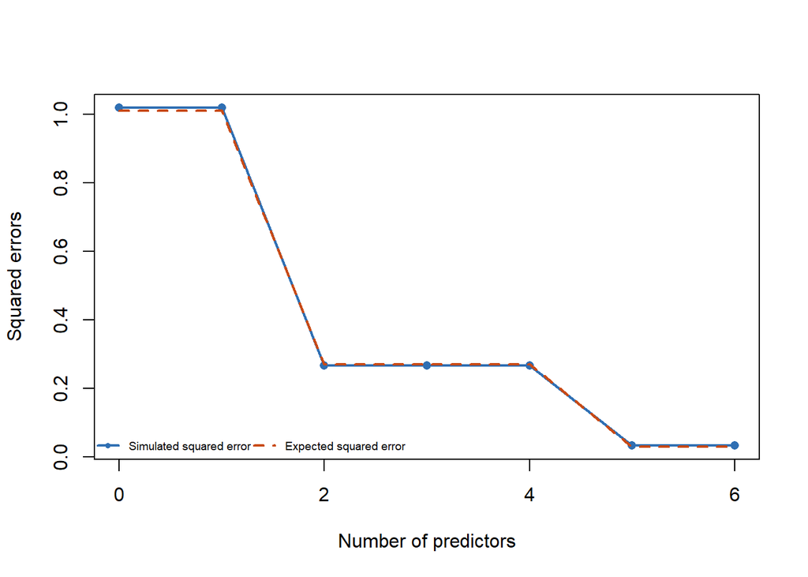

The smallest m that minimizes the theoretical error are m = 5 and m = 6.

3. All six regression coefficients are nonzero. Explain why only predictors 2 and 5 contribute directly to the mean response at $\mathbf x_0$. Contrast this target-specific error with the test MSE averaged over all rows of $\mathbf X_{\mathrm{all}}$ in Question 1.

   Only predictors 2 and 5 contribute directly to the mean response at x0 because x0 contains 1 at m = 2 and m = 5. This target-specific error measures prediction error at one point, x0. The test MSE averaged over all rows of X_all in Question 1 measures the mean prediction error over all 100 rows of the design matrix.

## Question 3: The optimism correction

Choose one candidate model before observing the response. Let $p$ be its number of predictors and let $\mathbf X\in\mathbb R^{n\times(p+1)}$ be its full-rank design matrix, including the intercept. The model has $p+1$ fitted coefficients. Let

$$\mathbf H
=\mathbf X
(\mathbf X^{\mathsf T}\mathbf X)^{-1}
\mathbf X^{\mathsf T}$$

be its hat matrix. Suppose

$$\begin{aligned}
C_p
&=\frac{\operatorname{RSS}}{\widehat\sigma^2}-n+2(p+1),
&\qquad
\operatorname{AIC}^{\mathrm{red}}
&=n\log\left(\frac{\operatorname{RSS}}{n}\right)+2(p+1),
&\qquad
\operatorname{BIC}^{\mathrm{red}}
&=n\log\left(\frac{\operatorname{RSS}}{n}\right)+(p+1)\log(n).
\end{aligned}$$
$$\operatorname{MSE}_{\mathrm{train}}
=
\frac{1}{n}
\left\lVert
\mathbf y-\mathbf H\mathbf y
\right\rVert_2^2,
\qquad
\operatorname{MSE}_{\mathrm{test}}
=
\frac{1}{n}
\left\lVert
\mathbf y^*-\mathbf H\mathbf y
\right\rVert_2^2.$$

The conditional bias vector of the fitted mean is

$$E(\mathbf H\mathbf y\mid\mathbf X)-\boldsymbol\mu
=
-(\mathbf I_n-\mathbf H)\boldsymbol\mu.$$

Let $B^2$ denote the **total squared approximation bias**:

$$B^2
=\left\lVert
(\mathbf I_n-\mathbf H)\boldsymbol\mu
\right\rVert_2^2.$$

Thus, $B^2/n$ is the mean squared approximation bias.

You may use

$$\mathbf H^{\mathsf T}=\mathbf H,
\qquad
\mathbf H^2=\mathbf H,
\qquad
\operatorname{tr}(\mathbf H)=p+1.$$

For any fixed matrix $\mathbf A$, you may also use

$$E\!\left(
\boldsymbol\epsilon^{\mathsf T}
\mathbf A
\boldsymbol\epsilon
\mid \mathbf X
\right)
=\sigma^2\operatorname{tr}(\mathbf A).$$

1. Derive

$$\begin{aligned}
E(\operatorname{MSE}_{\mathrm{train}}\mid\mathbf X)
&=\frac{B^2}{n}+\sigma^2\left(1-\frac{p+1}{n}\right),
&\qquad
E(\operatorname{MSE}_{\mathrm{test}}\mid\mathbf X)
&=\frac{B^2}{n}+\sigma^2\left(1+\frac{p+1}{n}\right).
\end{aligned}$$

Substitute y into MSE_train and distribute

$$\ y - \ Hy = (\ I_n - H)(\mu + \epsilon) = (\ I_n - H)\mu + (\ I_n - H)\epsilon$$

The squared length of the conditional bias vector of the fitted mean is B^2, the total squared approximation bias. For the error term,

$$E\!\left(
\boldsymbol\epsilon^{\mathsf T}
\mathbf A
\boldsymbol\epsilon
\mid \mathbf X
\right)
=\sigma^2\operatorname{tr}(\mathbf A).$$
where

$$A = (I_n - H)^2 = I_n - H$$

because the square of the hat matrix is the hat matrix itself (H^2 = H). Therefore,

$$tr(A) = tr(I_n - H) = n - (p + 1)$$

Putting it all together, we get E(MSE_train | X).

Substitute y and y* into MSE_test and rearrange

$$y^* - Hy = \mu + \epsilon^* - H(\mu + \epsilon) = (I_n - H)\mu + \epsilon^* - H\epsilon$$

The leftmost term is the total squared approximation bias. We know that the error is

$$E(||\epsilon^*||^2_2) = n\sigma^2$$

The rightmost term can be evaluated to

$$\sigma^2tr(H) = \sigma^2tr(H)=(p+1)\sigma^2$$

Thus, we get E(MSE_test | X).

2. Deduce the expected optimism, defined as $E(\operatorname{MSE}_{\mathrm{test}}-\operatorname{MSE}_{\mathrm{train}}\mid\mathbf X)$. For

$$n=120,
\qquad
p=4,
\qquad
\frac{B^2}{n}=0.04,
\qquad
\sigma^2=1,$$

calculate the expected training MSE, expected test MSE, and their difference. Explain why the ordering need not hold for every realized pair of responses.

```
                  label       value
1 expected training MSE  0.99833333
2     expected test MSE  1.08166667
3            difference -0.08333333
```

The ordering does not need to hold for every realized pair of responses because the expected MSE and test MSE describe the average behavior over many possible samples.

3. Continue with $n=120$ and $p=4$. Suppose the candidate model has residual sum of squares $\operatorname{RSS}=116.4$, and suppose a common estimate of the error variance is $\widehat\sigma^2=0.96$.

Calculate

$$\begin{aligned}
\widehat{\operatorname{MSE}}_{\mathrm{test}}
&=\frac{\operatorname{RSS}+2(p+1)\widehat\sigma^2}{n},
&\qquad
C_p
&=\frac{\operatorname{RSS}}{\widehat\sigma^2}-n+2(p+1).
\end{aligned}$$

Show how these two quantities are related, and explain why minimizing $C_p$ is equivalent to minimizing the corrected test MSE when $n$ and $\widehat\sigma^2$ are common to all candidate models.

MSE_test_hat is 1.05 and Cp is 11.25. If we plug in Cp into MSE_test_hat, we get

$$\widehat{\operatorname{MSE}}_{\mathrm{test}}
=\frac{\sigma^2
}{n}(C_p + n)= \sigma^2(1 + \frac{C_p}{n})$$

Minimizing Cp is equivalent to minimizing the corrected test MSE when n and sigma^2 are common to all candidate models because only Cp is changing in the MSE_test_hat formula above. This means as Cp decreases, MSE_test_hat decreases.

## Question 4: Comparing Mallows $C_p$, AIC, and BIC

Use `data/diabetes.csv`, with `y` as the response. Use rows 1 through 370 as the training data, and let $n=370$ denote the training sample size. Do not use rows 371 through 442 in this question. Fit the following ordinary least-squares models, each with an intercept.

| Model | Predictors | $p$ |
| --- | --- | --- |
| Model A | `bmi`, `bp`, `s5`, `sex`, `s1`, `s2`, `s4` | 7 |
| Model B | all predictors in Model A, followed by `s6` | 8 |
| Full reference | all ten predictors | 10 |

Here $p$ counts predictors, so each model has $p+1$ fitted coefficients including the intercept. Estimate one common noise variance from the full reference model, using $p=10$:

$$\widehat\sigma^2
=\frac{\operatorname{RSS}_{\mathrm{full}}}{n-(p+1)}.$$

For Models A and B, calculate

$$C_p
=\frac{\operatorname{RSS}}{\widehat\sigma^2}
-n+2(p+1),$$

$$\operatorname{AIC}^{\mathrm{red}}
=n\log\left(\frac{\operatorname{RSS}}{n}\right)+2(p+1),$$

and

$$\operatorname{BIC}^{\mathrm{red}}
=n\log\left(\frac{\operatorname{RSS}}{n}\right)
+(p+1)\log(n).$$

The reduced AIC and BIC omit constants shared by the two candidate models. Smaller values are preferred within each criterion.

1. Fit the three models. Report $p$, RSS, the residual degrees of freedom of the full model, and $\widehat\sigma^2$.

   ```
              model predictor     RSS
   1        Model A         8 1098909
   2        Model B         9 1089717
   3 Full reference        11 1089452
   ```

   ```
     Validation     Penalty
   1         Cp 5969.598472
   2        AIC    2.000000
   3        BIC    5.913503
   ```

## Question 5: Validation and final test data

Use rows 1 through 370 of `diabetes.csv` as the training data and rows 371 through 442 as the final test data. Consider eleven nested candidate models. For $m=0,1,\ldots,10$, the model with $m$ predictors contains an intercept and the first $m$ predictors in this order:

`age`, `sex`, `bmi`, `bp`, `s1`, `s2`, `s3`, `s4`, `s5`, `s6`.

An analyst proposes the following procedure:

1. Fit all eleven candidate models using the training data.
2. Calculate the MSE of each model on the final test data.
3. Select the model with the smallest test MSE.
4. Report that minimum as the final estimate of prediction error.

The analyst argues that the procedure is valid because the final test data were not used to estimate the regression coefficients.

1. Identify the first step that misuses the final test data. Explain why the minimum of eleven test MSE values is generally too favorable as an estimate of the selected procedure’s future prediction error.

   Step 2 is where the procedure misuses the final testing data because the data is used to evaluate all models before a model is chosen. The final testing data is no longer unbiased because the testing data was apart of the model selection. The minimum of the eleven test MSE values is generally too favorable as an estimate of the selected procedure’s future prediction error because random variation may cause one model to be too accurate.
2. Rewrite the analysis using five-fold cross-validation within the training data. State how the predictor count is selected, what is refitted, and when the final test data may be used.
   1. Split the training data into 5 random equal subsets.
   2. For each of the 11 candidate models, fit the model using 4 of the 5 subset, calculate the MSE from the 1 remaining subset, and repeat the process until each subset has been used to calculate the MSE.
   3. Average the five MSE values for each model.
   4. Select the model predictors with the smallest MSE.
   5. Use the predictors to fit a model with the entire dataset.
   6. Use rows 371 to 442 as the final test data to calculate the MSE.
3. Suppose the analyst has already examined all eleven test MSE values. What can still be reported transparently, and what additional data would be needed for a new final evaluation?

   The analyst can still report the eleven MSEs they calculated, the model they selected, and the final estimate of the prediction error. However, they should state that the final MSE they calculated is optimistic because the final test data was used in the selection of the model. A new, unused data set would be needed for a final evaluation.

## Reference

James, Witten, Hastie, Tibshirani, and Taylor, [*An Introduction to Statistical Learning*](https://www.statlearning.com/), Chapters 3, 5, and 6.